# HW2_2

Maria Firulyova

```r
library(data.table)
library(dplyr)
library(magrittr)
library(ggplot2)
library(tidyr)
library(plyr)
```

Load data, remove NA, transform some character variables to factor

```r
set.seed(1)
air_q <- fread('~/Загрузки/AirQualityUCI.csv', dec=',') %>% select(-c('V16', 'V17'))
air_q <- air_q %>%
  mutate(Date = as.factor(Date)) %>%
  mutate(Time = as.factor(Time))
air_q <- sapply(select_if(air_q, is.numeric),
                function(x) ifelse (x < 0, NA, x)) %>%
  as.data.frame() %>%
  drop_na()

air_q_long <- air_q %>% melt()
```

Heatmap: spearman correlations

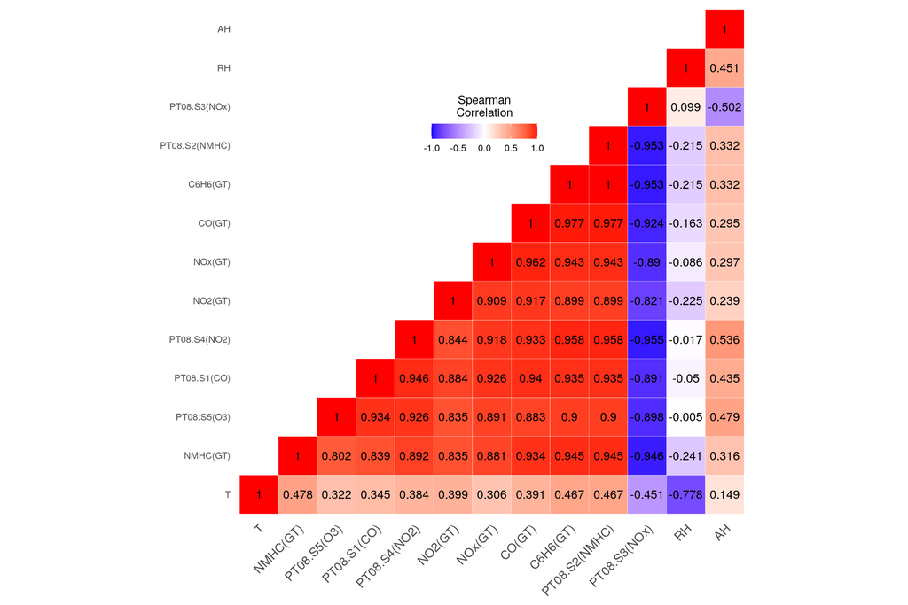

```r
get_upper_tri <- function(cormat){
  cormat[lower.tri(cormat)]<- NA
  cormat
}

reorder_cormat <- function(cormat){
  dd <- as.dist((1-cormat)/2)
  hc <- hclust(dd)
  cormat <-cormat[hc$order, hc$order]
}

cor_mat <- cor(air_q, use = "complete.obs", method = "spearman")
cor_mat <- reorder_cormat(cor_mat)
upper_tri <- get_upper_tri(cor_mat)
melted_cormat <- melt(upper_tri, na.rm = TRUE) %>% mutate(value = round(value, 3))
ggheatmap <- ggplot(melted_cormat, aes(Var2, Var1, fill = value))+
  geom_tile(color = "white")+
  scale_fill_gradient2(low = "blue", high = "red", mid = "white",
                       midpoint = 0, limit = c(-1,1), space = "Lab",
                       name="Spearman\nCorrelation") +
  theme_minimal()+
  theme(axis.text.x = element_text(angle = 45, vjust = 1,
                                   size = 12, hjust = 1))+
  coord_fixed()
ggheatmap+
  geom_text(aes(Var2, Var1, label = value), color = "black", size = 4) +
  theme(
    axis.title.x = element_blank(),
    axis.title.y = element_blank(),
    panel.grid.major = element_blank(),
    panel.border = element_blank(),
    panel.background = element_blank(),
    axis.ticks = element_blank(),
    legend.justification = c(1, 0),
    legend.position = c(0.6, 0.7),
    legend.direction = "horizontal")+
  guides(fill = guide_colorbar(barwidth = 7, barheight = 1,
                               title.position = "top", title.hjust = 0.5))
```

Since multicollinearity is a problem for linear regression, I remove some variables which correlated with the remained predictors. For this purpose, I use VIF criterion. The greater the VIF value, the stronger correlation is presented in the data. My *smart_model* function removes predictors until VIF will be < 5

Also, my *x* variable will be *CO(GT)*

```r
set.seed(1)

VIF <- function(data)
{
  sapply(names(data[-1]), function(name) {
    m = lm(as.formula(paste(name, "~ .")), data[-1])
    r2 = summary(m)$r.squared
    1 / (1 - r2)})
}

smart_model <- function(data) {
  vif_data <- sort(VIF(data), decreasing = T)
  while (sum(vif_data > 5) != 0) {
    remove <- names(vif_data)[1]
    data <- data[ , !(names(data) %in% remove)]
    vif_data <- sort(VIF(data), decreasing = T)
  }
  fit <- lm(data[,1] ~ ., data[-1])
}
```

Perform linear regression

```r
set.seed(1)
colnames(air_q) <- colnames(air_q) %>% stringr::str_replace_all("\\(|\\)|\\.", "")
fit1 <- smart_model(air_q)
summary(fit1)
```

```
##
## Call:
## lm(formula = data[, 1] ~ ., data = data[-1])
##
## Residuals:
##     Min      1Q  Median      3Q     Max
## -1.2036 -0.2758 -0.0513  0.1937  3.1754
##
## Coefficients:
##               Estimate Std. Error t value Pr(>|t|)
## (Intercept)  0.1536924  0.2671982   0.575  0.56531
## NMHCGT       0.0035830  0.0001252  28.610  < 2e-16 ***
## PT08S3NOx   -0.0004069  0.0001336  -3.046  0.00239 **
## NO2GT        0.0199190  0.0009501  20.965  < 2e-16 ***
## T           -0.0276429  0.0036655  -7.541 1.23e-13 ***
## AH           0.2383223  0.1061322   2.246  0.02500 *
## ---
## Signif. codes:  0 '***' 0.001 '**' 0.01 '*' 0.05 '.' 0.1 ' ' 1
##
## Residual standard error: 0.4569 on 821 degrees of freedom
## Multiple R-squared:  0.8956, Adjusted R-squared:  0.8949
## F-statistic:  1408 on 5 and 821 DF,  p-value: < 2.2e-16
```

All selected variables are statistically significant, and adjusted R-squared is high.

What if I transform my variables? For example, log-transformation usually leads to more linear relationships between variables, and also interpretable, which is really useful not only for prediction aims, but also for results interpretation.

Also, log-transformation can remvoe heteroscedastisity.

```r
set.seed(1)
log_air <- apply(air_q, 2, log10) %>% as.data.frame()
fit2 <- smart_model(log_air)
summary(fit2)
```

```
##
## Call:
## lm(formula = data[, 1] ~ ., data = data[-1])
##
## Residuals:
##      Min       1Q   Median       3Q      Max
## -0.21473 -0.04958 -0.00511  0.04733  0.46299
##
## Coefficients:
##             Estimate Std. Error t value Pr(>|t|)
## (Intercept) -1.99275    0.04403 -45.256  < 2e-16 ***
## NMHCGT       0.37930    0.01167  32.501  < 2e-16 ***
## NO2GT        0.83213    0.02846  29.240  < 2e-16 ***
## T           -0.15729    0.02166  -7.262 8.88e-13 ***
## AH           0.06097    0.02960   2.060   0.0397 *
## ---
## Signif. codes:  0 '***' 0.001 '**' 0.01 '*' 0.05 '.' 0.1 ' ' 1
##
## Residual standard error: 0.07388 on 822 degrees of freedom
## Multiple R-squared:  0.9293, Adjusted R-squared:  0.929
## F-statistic:  2701 on 4 and 822 DF,  p-value: < 2.2e-16
```

The adjusted R-squared of model which based on transformed data are bigger than the previous one.

Let’s use base *step* function for model selection (it’s based on AIC scores and it’s purpose is to find optimal number of predictors (the smaller the better) which describe the variance)

```r
set.seed(1)
optimal_fit <- step(lm(COGT ~ ., air_q), direction = 'backward')
```

```
## Start:  AIC=-2455.54
## COGT ~ PT08S1CO + NMHCGT + C6H6GT + PT08S2NMHC + NOxGT + PT08S3NOx +
##     NO2GT + PT08S4NO2 + PT08S5O3 + T + RH + AH
##
##              Df Sum of Sq    RSS     AIC
## - PT08S3NOx   1    0.0486 41.195 -2456.6
## <none>                    41.147 -2455.5
## - PT08S2NMHC  1    0.3811 41.528 -2449.9
## - PT08S4NO2   1    0.3953 41.542 -2449.6
## - RH          1    0.6850 41.832 -2443.9
## - AH          1    0.9160 42.063 -2439.3
## - T           1    1.7360 42.883 -2423.4
## - NO2GT       1    2.5799 43.727 -2407.2
## - NMHCGT      1    3.5229 44.670 -2389.6
## - PT08S5O3    1    3.9801 45.127 -2381.2
## - PT08S1CO    1    4.3164 45.463 -2375.0
## - C6H6GT      1    7.6381 48.785 -2316.7
## - NOxGT       1    8.9892 50.136 -2294.1
##
## Step:  AIC=-2456.57
## COGT ~ PT08S1CO + NMHCGT + C6H6GT + PT08S2NMHC + NOxGT + NO2GT +
##     PT08S4NO2 + PT08S5O3 + T + RH + AH
##
##              Df Sum of Sq    RSS     AIC
## <none>                    41.195 -2456.6
## - PT08S4NO2   1    0.3825 41.578 -2450.9
## - PT08S2NMHC  1    0.5746 41.770 -2447.1
## - RH          1    0.7820 41.977 -2443.0
## - AH          1    1.1738 42.369 -2435.3
## - T           1    1.9237 43.119 -2420.8
## - NO2GT       1    2.5493 43.745 -2408.9
## - NMHCGT      1    3.8891 45.085 -2384.0
## - PT08S5O3    1    4.0393 45.235 -2381.2
## - PT08S1CO    1    4.5708 45.766 -2371.6
## - NOxGT       1    9.1113 50.307 -2293.3
## - C6H6GT      1   12.7210 53.916 -2236.0
```

```r
summary(optimal_fit)
```

```
##
## Call:
## lm(formula = COGT ~ PT08S1CO + NMHCGT + C6H6GT + PT08S2NMHC +
##     NOxGT + NO2GT + PT08S4NO2 + PT08S5O3 + T + RH + AH, data = air_q)
##
## Residuals:
##      Min       1Q   Median       3Q      Max
## -0.74890 -0.14001 -0.00353  0.11977  1.19647
##
## Coefficients:
##               Estimate Std. Error t value Pr(>|t|)
## (Intercept)  7.886e-01  2.289e-01   3.445 0.000599 ***
## PT08S1CO     1.287e-03  1.353e-04   9.509  < 2e-16 ***
## NMHCGT       8.226e-04  9.378e-05   8.772  < 2e-16 ***
## C6H6GT       1.410e-01  8.890e-03  15.864  < 2e-16 ***
## PT08S2NMHC  -7.910e-04  2.346e-04  -3.371 0.000783 ***
## NOxGT        4.630e-03  3.448e-04  13.426  < 2e-16 ***
## NO2GT        4.780e-03  6.731e-04   7.102 2.69e-12 ***
## PT08S4NO2   -5.977e-04  2.173e-04  -2.751 0.006078 **
## PT08S5O3    -5.495e-04  6.147e-05  -8.939  < 2e-16 ***
## T           -4.684e-02  7.593e-03  -6.169 1.08e-09 ***
## RH          -1.041e-02  2.647e-03  -3.933 9.09e-05 ***
## AH           8.353e-01  1.733e-01   4.819 1.72e-06 ***
## ---
## Signif. codes:  0 '***' 0.001 '**' 0.01 '*' 0.05 '.' 0.1 ' ' 1
##
## Residual standard error: 0.2248 on 815 degrees of freedom
## Multiple R-squared:  0.9749, Adjusted R-squared:  0.9746
## F-statistic:  2877 on 11 and 815 DF,  p-value: < 2.2e-16
```

Let’s investigate some quality metrics of builded model. I write *hetero_test* function which test whether there is heteroscedasticity in the builded model or not

```r
hetero_test <-  function(fit, df){
  fit_2 <- lm(fit$residuals^2 ~., df[-1])
  summary(fit_2)
}

explore_model <- function(fit, df) {
  vals <- cbind(fit$residuals, fit$fitted.values) %>% as.data.frame()  %>% magrittr::set_colnames(c('residuals', 'fitted'))
  cols <- names(fit$coefficients)[2:length(fit$coefficients)]
  het_res <- hetero_test(fit, df %>%
                           select(cols))
  ggplot(vals, aes(x = residuals, y = fitted))+
    geom_point()+
    theme_bw()+
    ggtitle(sprintf('shapiro p-value: %f, r^2 lm(fit$residuals^2 ~ ., df): %f', shapiro.test(fit$residuals)$p.value, het_res$r.squared))
}
```

**1.1** fit1: COGT ~ NMHCGT + PT08S3NOx + NO2GT + T + AH

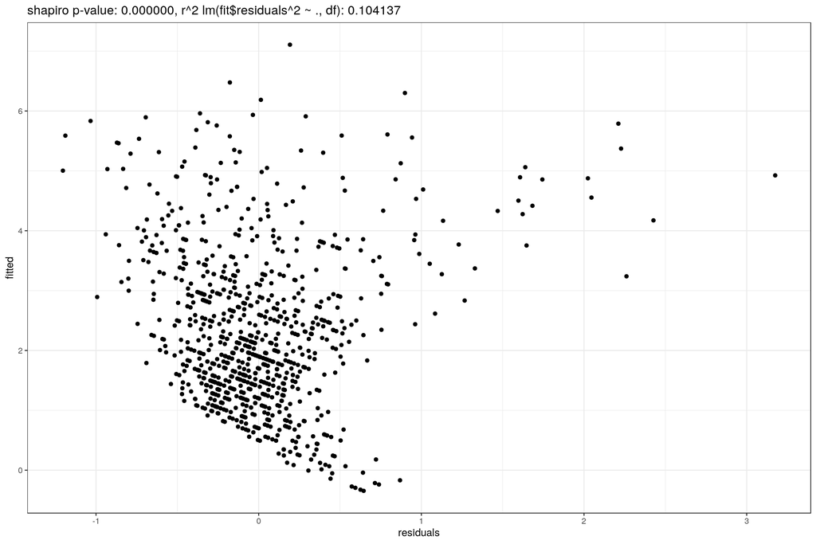

```r
set.seed(1)
explore_model(fit1, air_q)
```

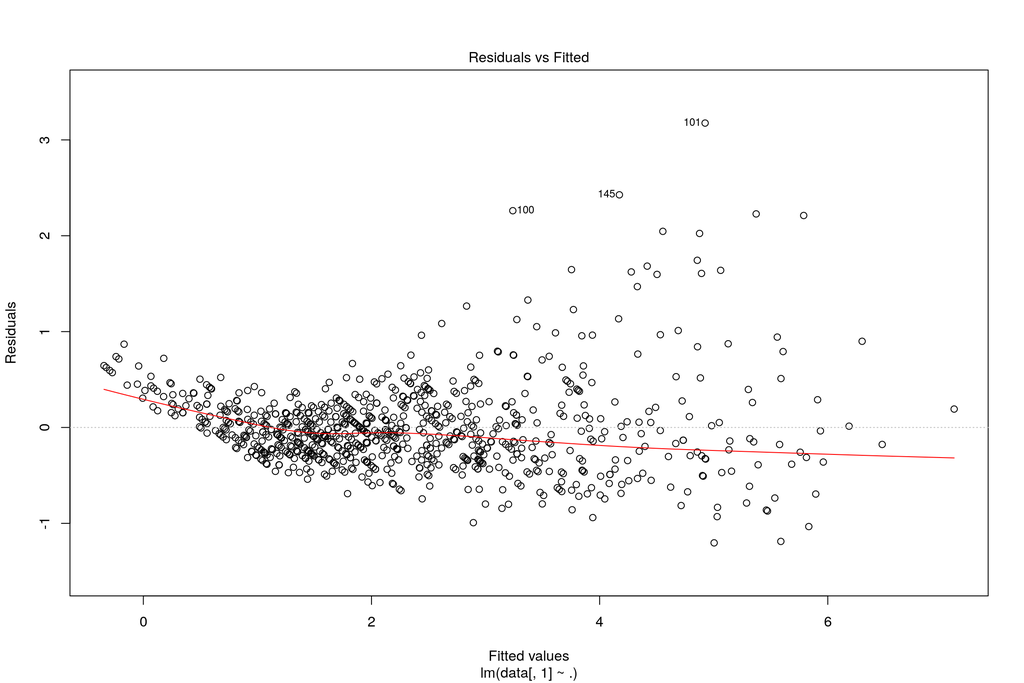

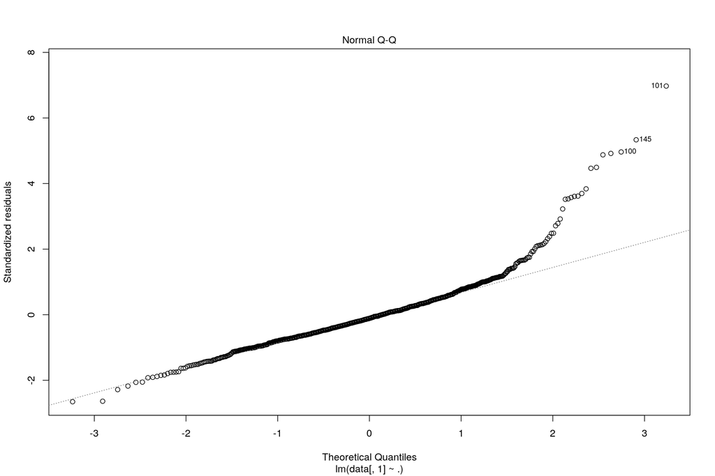

```r
plot(fit1, which= c(1, 2))
```

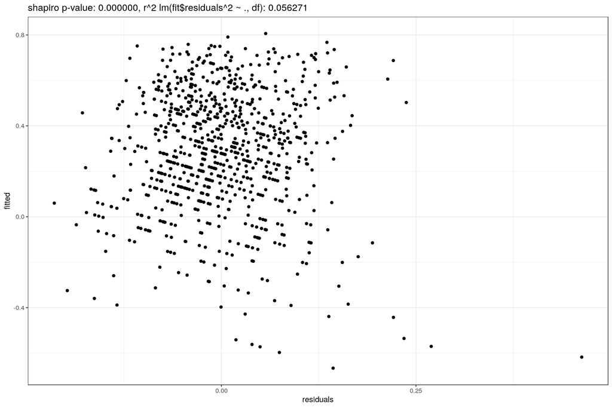

```r
set.seed(1)
explore_model(fit2, log_air)
```

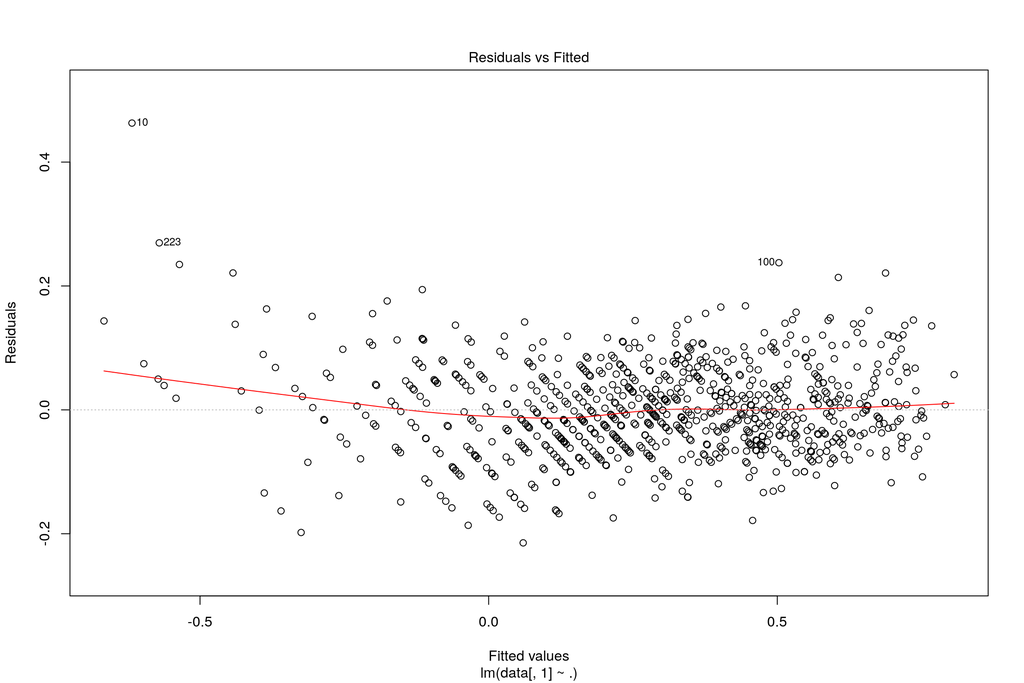

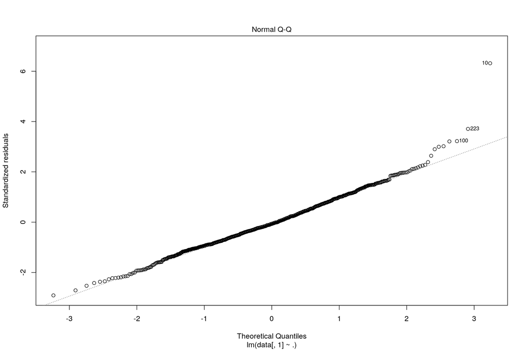

```r
plot(fit2, which= c(1, 2))
```

**1.3** fit3:

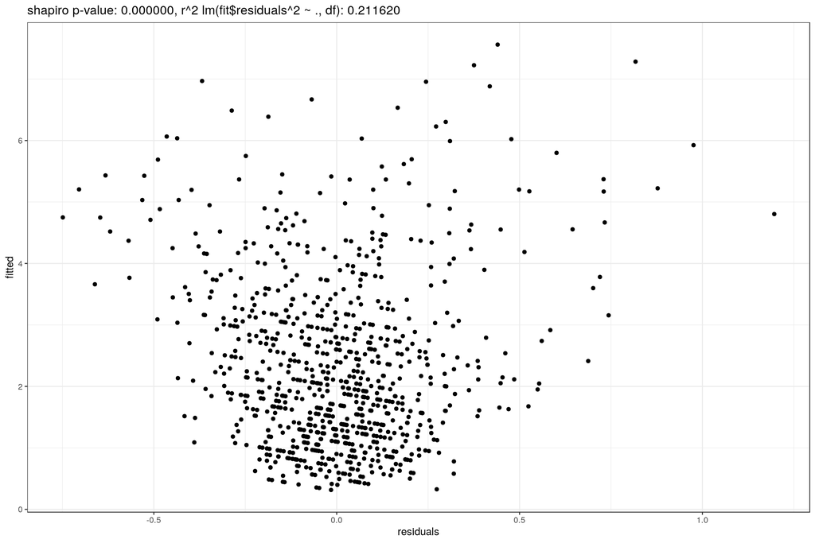

```r
set.seed(1)
explore_model(optimal_fit, air_q)
```

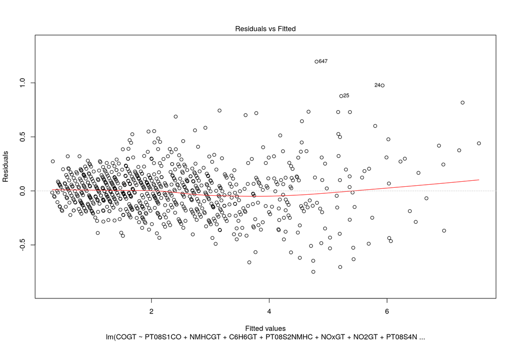

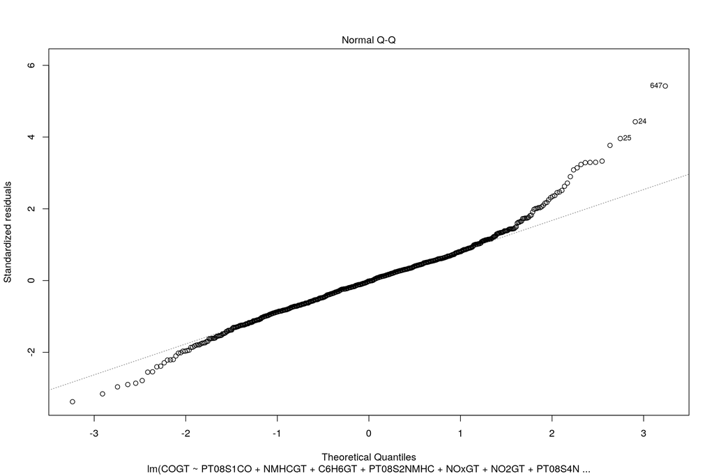

```r
plot(optimal_fit, which= c(1, 2))
```

I guess, the second model (log-transformation -> VIF selection) is the better than the *fit1* (VIF selection) and *optimal_fit* (step result) because it has smaller extent of heteroscedastisity (however it is still a problem, and residuals are not normally distributed).